# 10 Phycocyanin harmonization process

Following the completion of the `{dataRetrieval}` download process described previously, the pipeline contains raw WQP data for each parameter of interest. Before harmonizing each parameter, we run through a series of universal “pre-harmonization” steps to ensure consistent column types, site metadata, and time zones across the dataset.

Phycocyanin is a water-soluble phycobiliprotein accessory pigment characteristic of freshwater cyanobacteria, exhibiting an in-water absorption maximum near 620 nm and fluorescence emission near 645–650 nm (Simis et al., 2005; Randolph et al., 2008; Chorus and Welker, 2021). The sections below walk through the pre-harmonization and harmonization steps for phycocyanin, explaining how extractive laboratory pigment assays (`Phycocyanin`), *in situ* optical probe mass-equivalent estimates (`Phycocyanin (probe)`), *in vivo* relative probe fluorescence (`Phycocyanin relative fluorescence`), and sensor-estimated cyanobacterial cell counts (`Phycocyanin cell density`) are separated, cleaned, tiered, and flagged.

## 10.1 Pre-harmonization of the raw phycocyanin WQP dataset

At the start of the pre-harmonization process the raw phycocyanin WQP dataset contains 157.2 thousand rows.

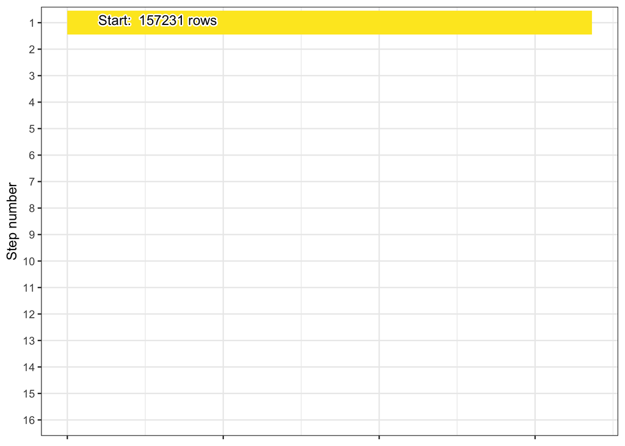

Bar plot showing the row count update for the current harmonization step.

### 10.1.1 Missing results

Next, rows flagged as truly missing results are dropped based on `"analysis lost"`, `"not analyzed"`, `"not recorded"`, `"not collected"`, or `"no measurement taken"` in `ResultCommentText` when no measurement value is available.

This step removes 1967 rows of data, leaving 155.3 thousand rows remaining.

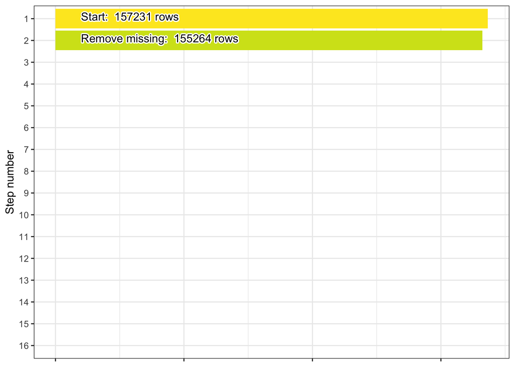

Bar plot showing the row count update for the current harmonization step.

### 10.1.2 Filter status

The final step in pre-harmonization filters `ResultStatusIdentifier` to retain only records with status:

- `"Accepted"`
- `"Final"`
- `"Historical"`
- `"Validated"`
- `"Preliminary"`
- `NA`

Records marked `"Provisional"` or other non-finalized statuses are dropped (766 rows), leaving 154.5 thousand rows remaining.

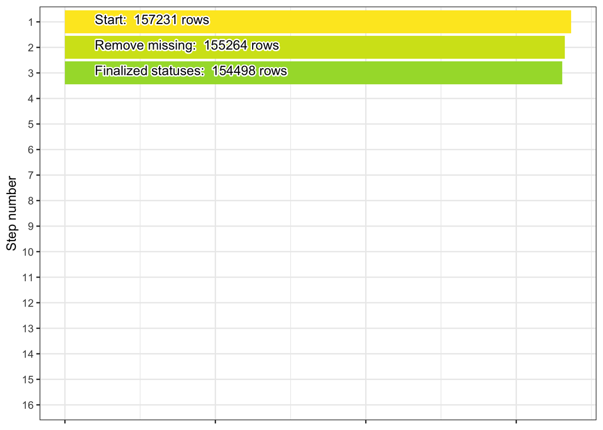

Bar plot showing the row count update for the current harmonization step.

## 10.2 Harmonization-ready phycocyanin dataset

Once ready for harmonization, the phycocyanin WQP dataset contains the following `CharacteristicName`s: Algae-Phycocyanin, Phycocyanin, Phycocyanin (probe), Phycocyanin (probe relative fluorescence), Phycocyanins.

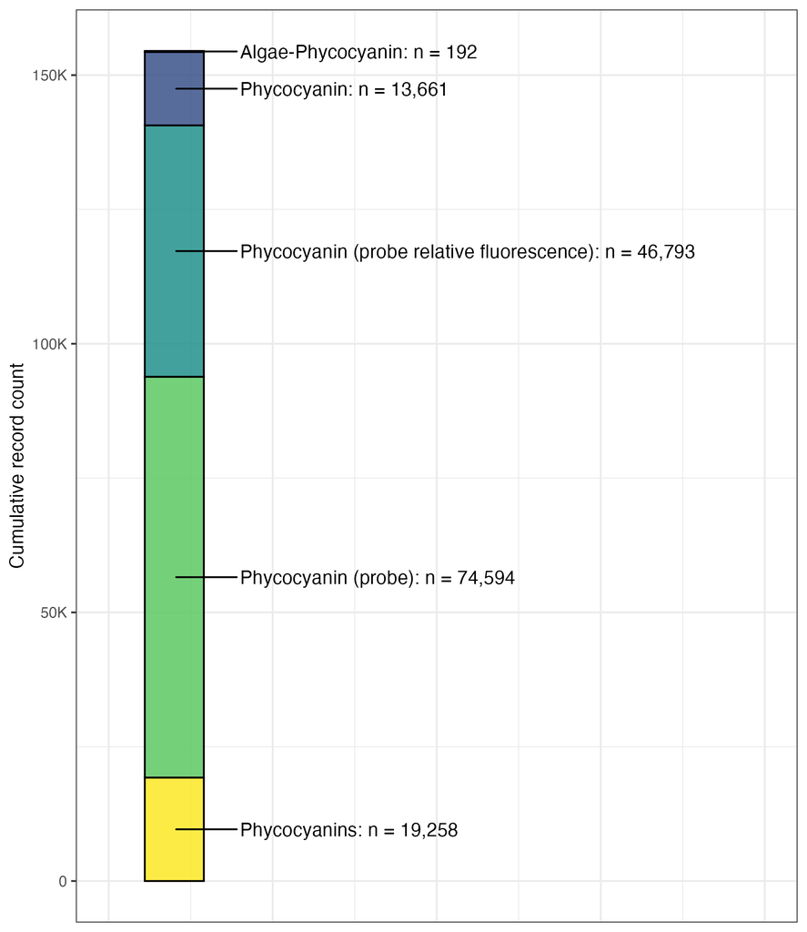

### 10.2.1 Filter media, non-target pigments, unit-misfiled batches, and daily summaries; categorize parameters

In this step, we first recover empty `ResultMeasure.MeasureUnitCode` entries from `DetectionQuantitationLimitMeasure.MeasureUnitCode` when non-detect rows report their units only in the detection-limit metadata. We then apply four domain-specific filters before assigning phycocyanin parameter categories:

1. **Water media and matrix filtering**: `ActivityMediaSubdivisionName` must be `"Surface Water"`, `"Water"`, `"Estuary"`, or `NA` (removing `"Ocean Water"`). Field quality-control blanks (`ActivityTypeCode` containing `"Blank"`) and benthic substrate scrapes (`"Periphyton"` in `SampleCollectionEquipmentName`) are also removed.
2. **Non-target pigment exclusion**: WQP submissions occasionally file accessory phycobiliprotein or chlorophyll fluorescence data under phycocyanin `CharacteristicName`s. Estuarine probe records annotated `"YSI - BGA-PE"` (phycoerythrin) in `ResultCommentText` or `ResultAnalyticalMethod.MethodName`, as well as USGS parameter codes for phycoerythrin, allophycocyanin, or `fChl`, are excluded.
3. **Unit-misfiled batch exclusion**: Historical audit checks show that `CA_BVR` transitioned from floating-point sensor `ug/L` outputs in 2016–2020 (`<= 1.2%` integer values) to integer cell-density readouts (`99.6--100%` integer values up to `2,000,000`) during 2021–2022 while retaining `"ug/L"` in `ResultMeasure.MeasureUnitCode`, before correcting the unit code to `"#/mL"` in 2023–2026. The mislabeled `2021--2022` `CA_BVR` `"ug/L"` batch is excluded here so cell counts are not conflated with pigment mass concentration.
4. **Daily statistical summary filtering**: Continuous water quality sondes frequently archive multiple daily summary statistics at the same station and date (`"Minimum"`, `"Maximum"`, `"Delta"`, `"Median"`, and `"Mean"`). Including extremes alongside central tendencies would collapse spreads into site averages during downstream aggregation, so non-central statistical summaries are dropped while retaining instantaneous (`NA`) and daily `"Mean"` records (which are subsequently flagged in `misc_flag`).

Even among surviving `ug/L` records, extractive laboratory assays and *in situ* optical probes measure fundamentally different physical quantities. Paired WQP sonde deployments reporting simultaneous `ug/L` and `RFU` channels demonstrate that probe `"ug/L"` outputs represent organization- or factory-specific linear Rhodamine-WT fluorescence scalings (e.g., median `ug/L : RFU` ratios of `1.00` across `USGS-CO`, `USGS-KS`, `USGS-TX`, and `CT_DEP01_WQX` versus `10.00` at `LADEQWPD_WQX` and `13.40` at `USGS-NV`) that remain vulnerable to non-photochemical quenching (NPQ; Rousso et al., 2021), inverse temperature sensitivity (~1% per deg C; Watras et al., 2017), cellular packaging self-shading, and dissolved organic matter / chlorophyll-*a* optical cross-talk (Zamyadi et al., 2012; Bertone et al., 2018; Foster et al., 2022). Because simultaneous-record aggregation drops `CharacteristicName` and `ResultAnalyticalMethod.MethodName`, surviving records are separated into four physically distinct `parameter` groups:

[output not shown]

Records excluded by the media/matrix, non-target pigment, unit-misfiled batch, or daily summary statistic filters are dropped (`n =` 83,603). A summary of excluded records is shown below:

```r
param_drop_record %>%
  kable() %>%
  kable_paper() %>%
  scroll_box(width = "750px", height = "450px")
```

| CharacteristicName | ResultAnalyticalMethod.MethodName | USGSPCode | ResultAnalyticalMethod.MethodIdentifier | ResultAnalyticalMethod.MethodIdentifierContext | ResultMeasure.MeasureUnitCode | ResultSampleFractionText | n |
| --- | --- | --- | --- | --- | --- | --- | --- |
| Phycocyanin (probe) | NA | NA | NA | NA | ug/L | NA | 60113 |
| Phycocyanin (probe relative fluorescence) | Multiparameter Water Quality Sonde | NA | EXO WQ sonde | YSI | RFU | NA | 10245 |
| Phycocyanin (probe relative fluorescence) | NA | NA | NA | NA | RFU | NA | 9728 |
| Phycocyanin | NA | NA | NA | NA | ug/L | NA | 3253 |
| Phycocyanin | Multiparameter Water Quality Sonde | NA | EXO WQ sonde | YSI | RFU | NA | 260 |
| Phycocyanin | Phycocyanin in Water by Fluorometry | NA | FLUOROMETRY | MASSDEP | mg/m3 | None | 3 |
| Phycocyanins | NA | 32319 | NA | NA | ug/l | Total | 1 |

Below is a stacked barplot of the dataset organized by the assigned `parameter` column:

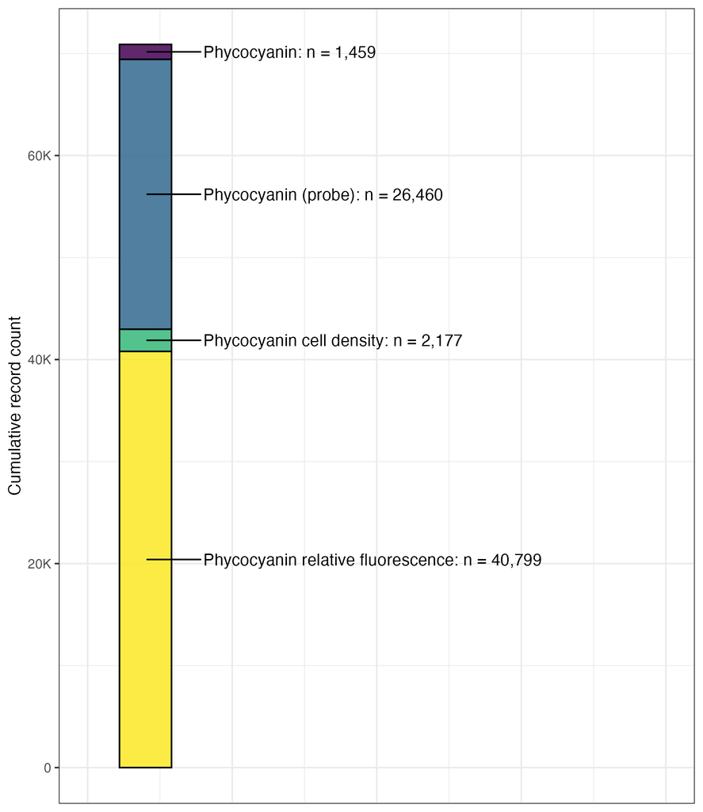

83.6 thousand rows are removed, leaving 70.9 thousand rows remaining.

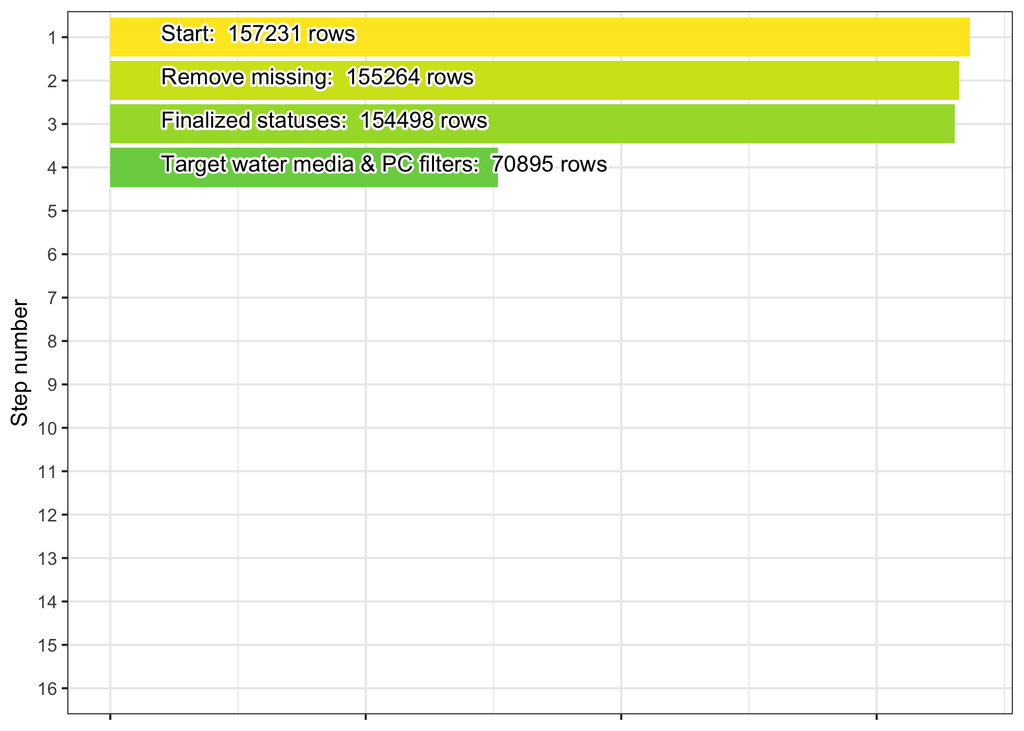

Bar plot showing the row count update for the current harmonization step.

### 10.2.2 Document and remove fails

In this step we filter out records containing disqualifying WQX `MeasureQualifierCode` flags (`"FQC"`, `"R"`, `"SUS"`, `"QCI"`) as well as failure, biofouling pre-clean audit, or sensor-malfunction language across `ActivityCommentText`, `ResultLaboratoryCommentText`, `ResultCommentText`, `ResultDetectionConditionText`, and `ResultMeasureValue_original` (the character copy of `ResultMeasureValue` prior to numeric coercion).

Following continuous monitoring QA conventions (Wagner et al., 2006) and phycocyanin WQP comment screening—while preserving benign environmental notes such as `"DO probe unstable"`, `"warm day"`, `"broken clouds"`, or unrelated selenium/pH criteria—we exclude `"PreClean"` biofouling/drift checks, non-deployed streambank audits, and `"not logging"` / `"readings will not settle"` notes alongside standard failure phrases: `"beyond accept"`, `"cancelled"`, `"contaminat"`, `"error"`, `"fail"`, `"improper"`, `"instrument down"`, `"interference"`, `"invalid"`, `"no result"`, `"no sample"`, `"no test"`, `"not accept"`, `"outside of accept"`, `"problem"`, `"questionable"`, `"suspect"`, `"unable"`, `"violation"`, `"reject"`, `"no data"`, `"value extrapolated"`, `"criteria exceed"`, `"biased"`, `"parameter not required"`, `"not visited"`, `"warm sample"`, `"broken bottle"`, `"broken cooler"`, `"received broken"`, `"broken sensor"`, `"time not documented"`, `"wiper stopped"`, `"wiper not parked"`, `"sonde out of water"`, `"sonde stopped recording"`, `"not logging"`, `"not recording"`, `"not deployed"`, `"audit at streambank"`, `"preclean"`, `"pre-clean"`, `"readings will not settle"`, `"reading high on bga"`, `"stopped working"`, `"not working"`, `"off scale"`, and `"censored"`.

Below are pie charts summarizing failure phrase and qualifier detections for each column that contained matches (note that detections are not mutually exclusive):

#### 10.2.2.1 ActivityCommentText fail detects

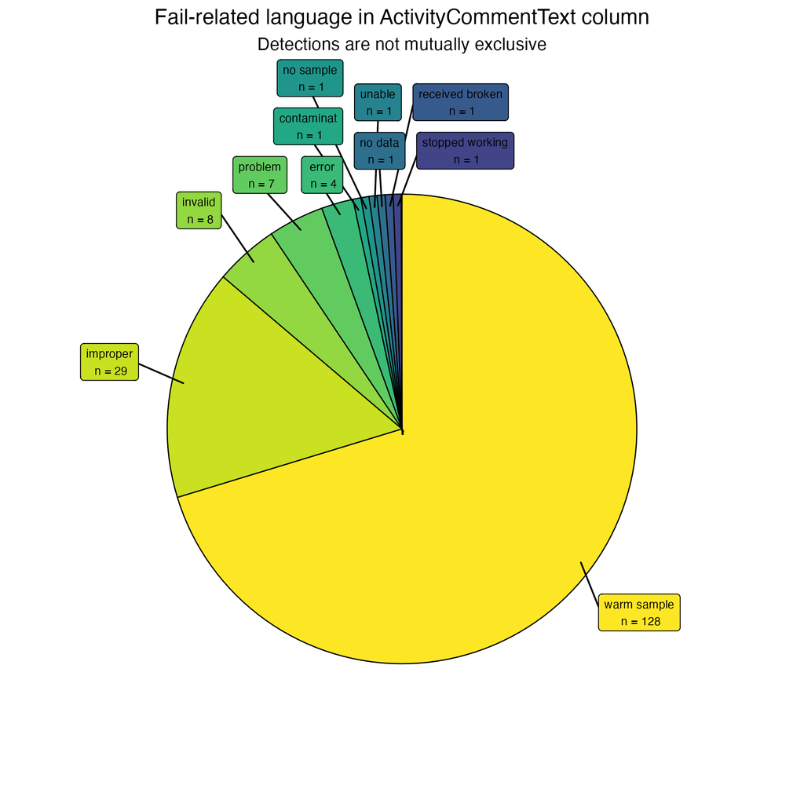

#### 10.2.2.2 MeasureQualifierCode fail detects

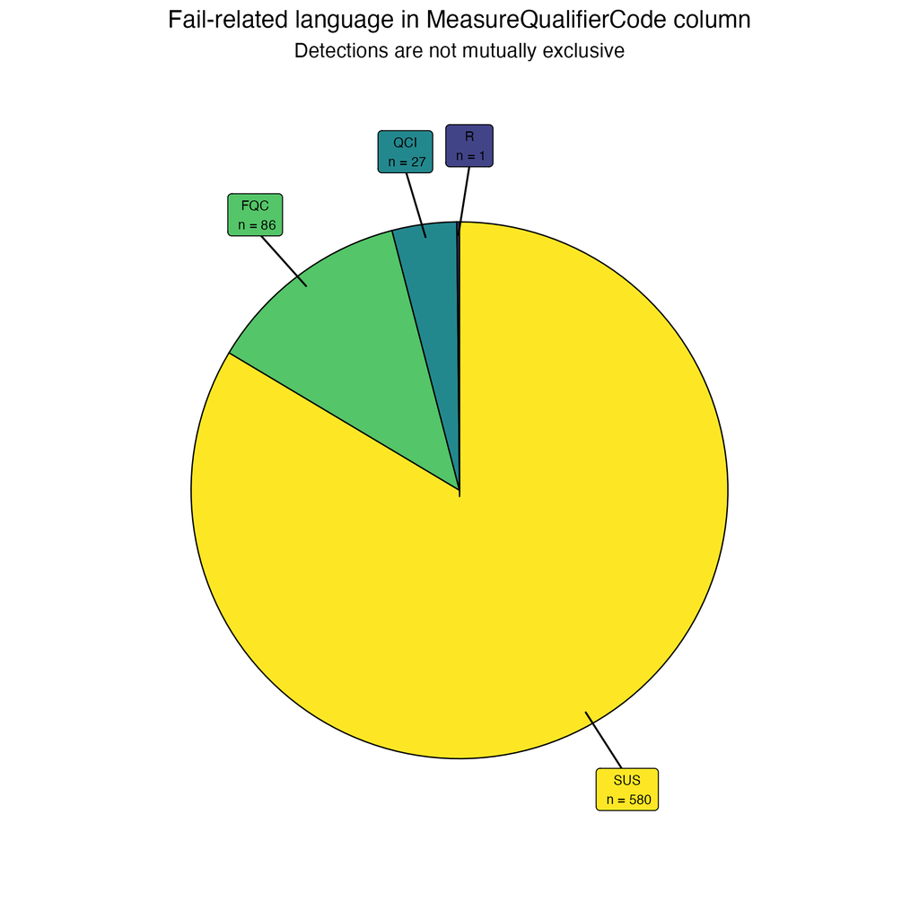

#### 10.2.2.3 ResultCommentText fail detects

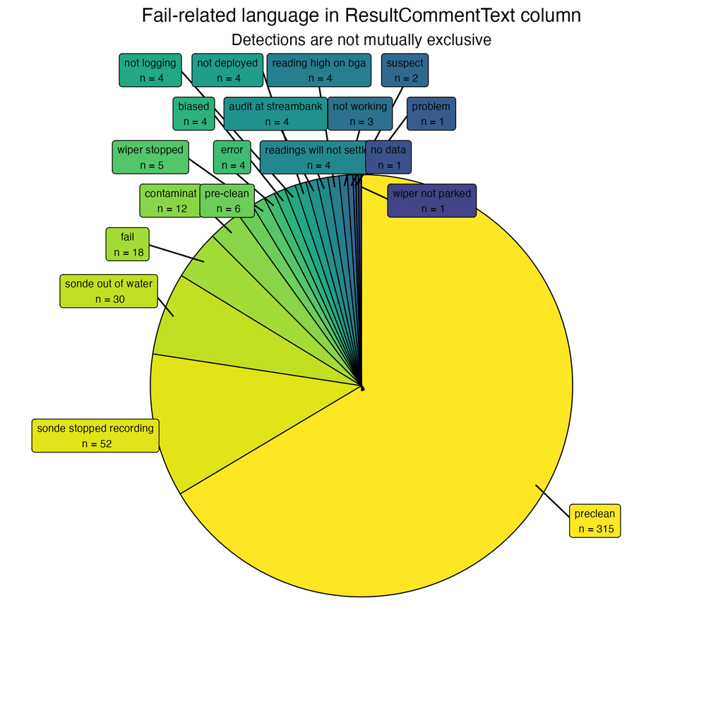

#### 10.2.2.4 ResultLaboratoryCommentText fail detects

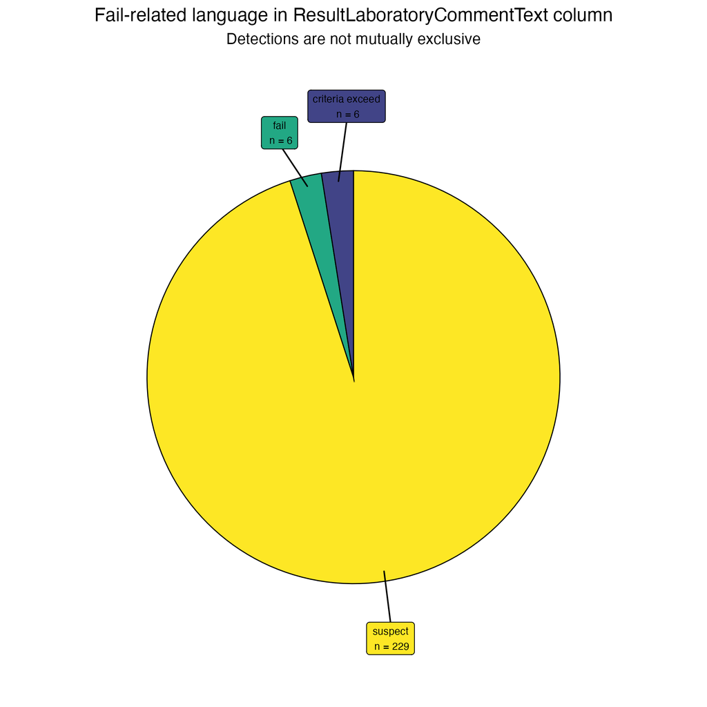

#### 10.2.2.5 ResultMeasureValue_original fail detects

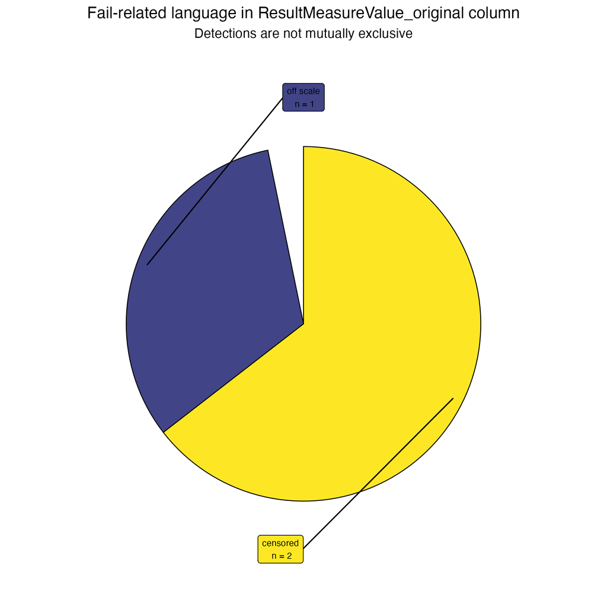

1241 rows are removed after detecting failure-related phrases and 69.7 thousand rows remain.

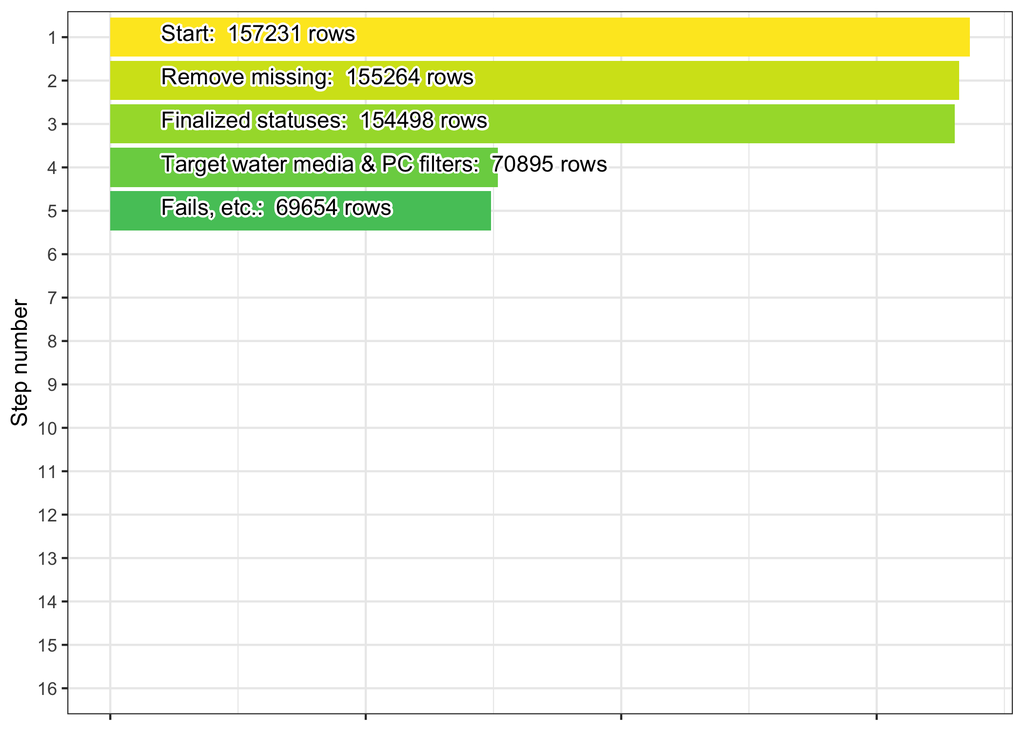

Bar plot showing the row count update for the current harmonization step.

### 10.2.3 Clean MDLs

Method detection limits (MDLs) are cleaned following AquaMatch conventions, with two phycocyanin-specific safeguards: in addition to `NA` values carrying non-detect indicators (`"non-detect"`, `"not detect"`, `"non detect"`, `"undetect"`, `"below"`, `"Present <QL"`, `"ND"`, `"nd"`) or `<` numeric text in `ResultMeasureValue_original`, numeric zeros explicitly flagged as censored (`MeasureQualifierCode == "U"` or non-detect text in `ResultDetectionConditionText`, e.g., `EPA_R7_WQX` `"Below Reporting Limit"`) are imputed when their reported limit is strictly positive (`MDL > 0`), drawing uniformly between `0` and `0.5 * MDL` while preserving units from `DetectionQuantitationLimitMeasure.MeasureUnitCode` when `ResultMeasure.MeasureUnitCode` is blank. Zero-valued limits (`LRL = 0` or `<0`) are left unadjusted rather than passed to `runif(0, 0)`.

The `mdl_flag` column records `0` (unadjusted at/above MDL), `1` (imputed using EPA `0` to `0.5 * MDL`), or `2` (reported numeric value below MDL, unadjusted).

This step drops 0 rows, leaving 69.7 thousand remaining.

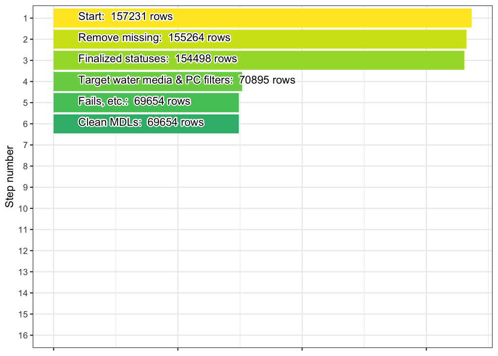

Bar plot showing the row count update for the current harmonization step.

### 10.2.4 Clean approximate values

Records with missing numeric `ResultMeasureValue` that contain numeric text and approximation phrases (`"result approx"`, `"RESULT IS APPROX"`, `"value approx"`) are cleaned and flagged (`approx_flag = 1`), while unadjusted rows receive `approx_flag = 0`.

This step drops 0 rows, leaving 69.7 thousand rows remaining.

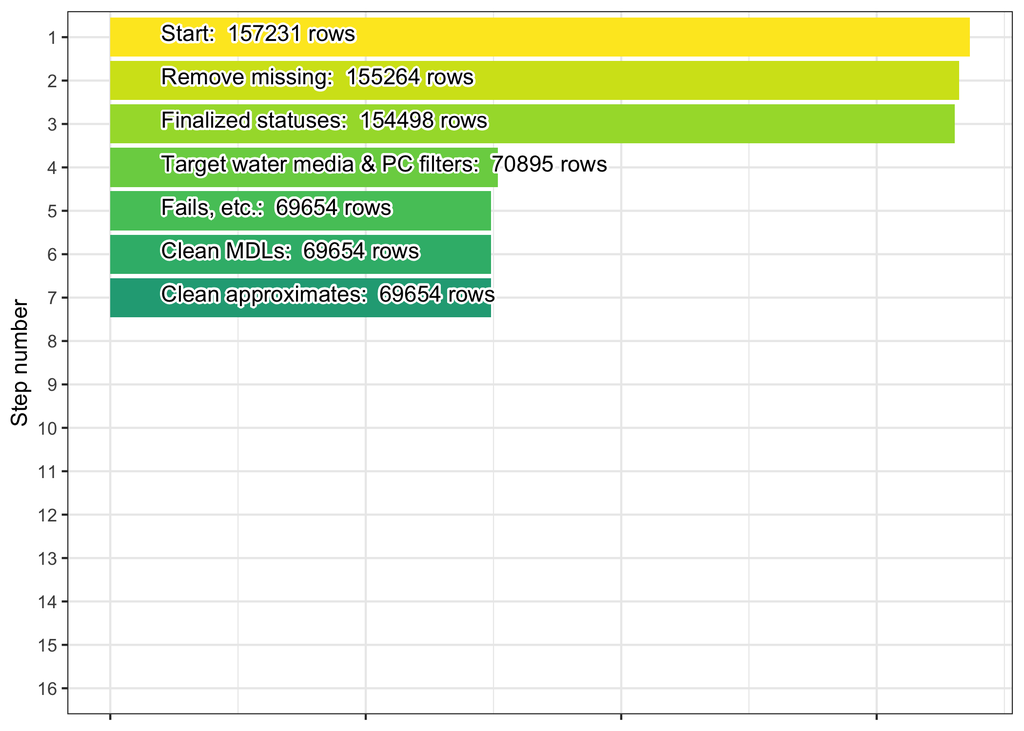

Bar plot showing the row count update for the current harmonization step.

### 10.2.5 Clean values with “greater than” data

Similarly, unadjusted records containing `>` qualifiers in `ResultMeasureValue_original` (stripping `>`, `=`, and `*`), as well as `NA` records marked `"Present Above Quantification Limit"` in `ResultDetectionConditionText` with a positive `DetectionQuantitationLimitMeasure.MeasureValue`, are recovered and flagged (`greater_flag = 1`), leaving all other records with `greater_flag = 0`.

0 rows are removed, leaving 69.7 thousand rows remaining.

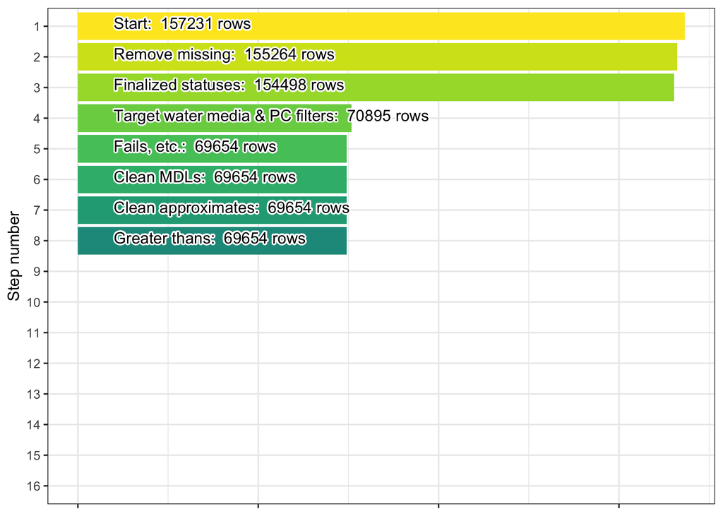

Bar plot showing the row count update for the current harmonization step.

### 10.2.6 Drop unresolved NA and negative measurements

Following non-detect, approximate, and greater-than recovery, remaining unresolved `NA`/`NaN` values and negative measurements (`harmonized_value < 0`, which occur primarily as zero-offset baseline drift on continuous optical sondes) are removed because neither pigment concentrations, positive relative fluorescence, nor cell counts can be physically negative.

4128 rows are removed, leaving 65.5 thousand rows remaining.

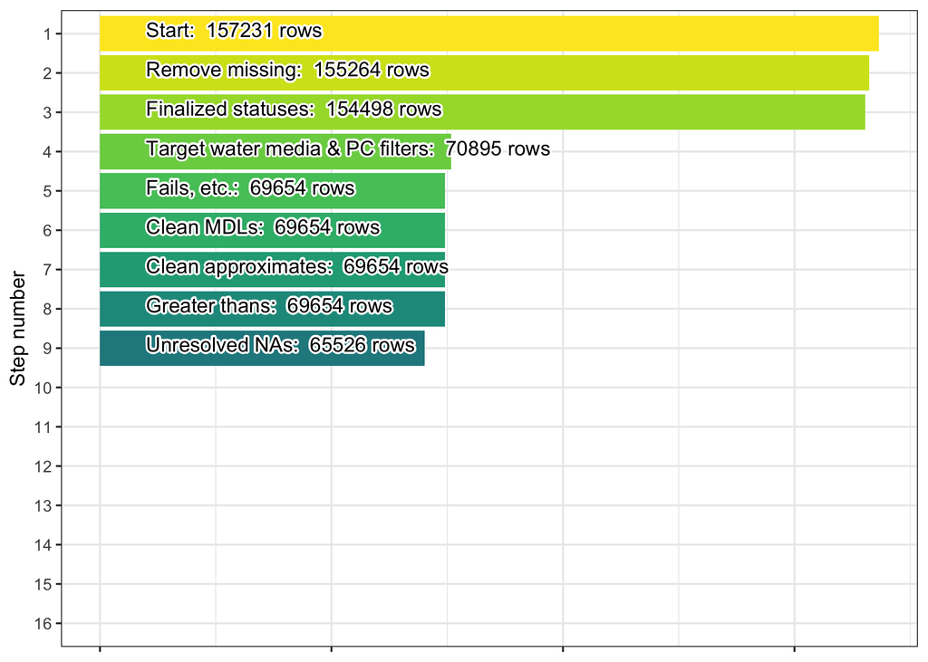

Bar plot showing the row count update for the current harmonization step.

### 10.2.7 Harmonize record units

Each parameter group is converted to a single canonical unit using the conversion table below: laboratory and probe mass concentrations (`ug/l`, `ug/L`, `mg/m3`, `ppb`, `mg/L`, `mg/l`, `ppm`, `ug/ml`, `ug/mL`, `mg/cm3`) convert to `"ug/L"`; relative fluorescence units retain `"RFU"` or `"IVFU"`; and cell-density units (`#/mL`, `#/ml`, `cells/mL`) normalize to `"#/mL"`. Note that `Phycocyanin` and `Phycocyanin (probe)` share `"ug/L"` as `harmonized_units` while remaining strictly segregated in the `parameter` column.

| ResultMeasure.MeasureUnitCode | harmonized_units | conversion |
| --- | --- | --- |
| mg/l | ug/L | 1000 |
| mg/L | ug/L | 1000 |
| ppm | ug/L | 1000 |
| ug/l | ug/L | 1 |
| ug/L | ug/L | 1 |
| mg/m3 | ug/L | 1 |
| ppb | ug/L | 1 |
| mg/cm3 | ug/L | 1e+06 |
| ug/ml | ug/L | 1000 |
| ug/mL | ug/L | 1000 |
| RFU | RFU | 1 |
| IVFU | IVFU | 1 |
| #/mL | #/mL | 1 |
| #/ml | #/mL | 1 |
| cells/mL | #/mL | 1 |

0 rows are removed due to unconvertible unit codes (all surviving rows mapped cleanly onto the unit conversion table), leaving 65.5 thousand rows remaining.

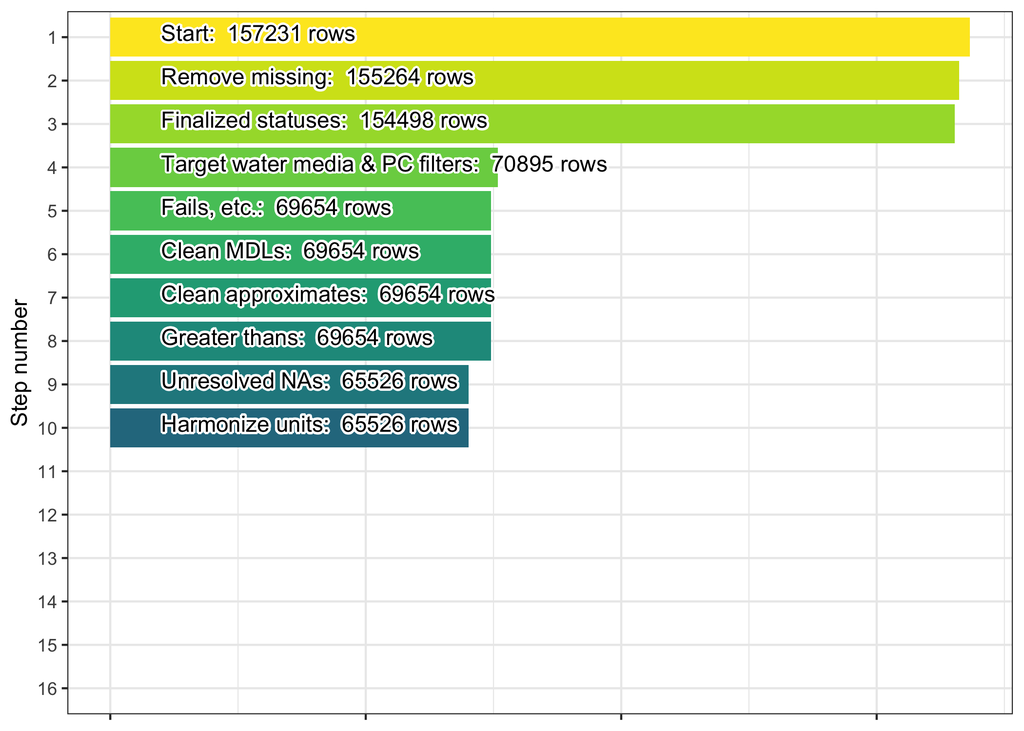

Bar plot showing the row count update for the current harmonization step.

### 10.2.8 Clean depth data

The four WQP depth columns are standardized to meters and summarized via `depth_flag` as documented in the *Tiering, flagging, and quality control philosophy* chapter (`0` = no depth, `1` = discrete depth, `2` = integrated top/bottom depths, `3` = both discrete and integrated depths present).

0 rows are removed, leaving 65.5 thousand rows remaining.

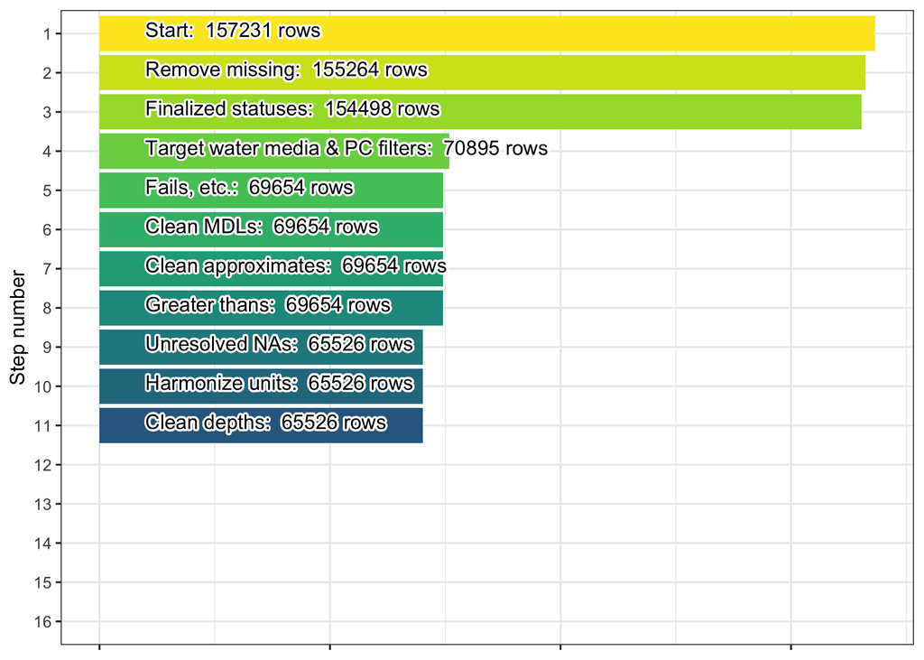

Bar plot showing the row count update for the current harmonization step.

### 10.2.9 Filter and tier methods

In preparation for tiering, clearly misassigned non-phycocyanin laboratory methods (Standard Methods `4500-P B` phosphorus sample preparation) are filtered out. Remaining records are assigned to three analytical method tiers separating documented aqueous pigment extraction protocols from unextracted *in situ* optical sensors and missing or incompatible method entries:

| Tier | Name | Description | Phycocyanin Details |
| --- | --- | --- | --- |
| 0 | Restrictive | Data that are verifiably self-similar across organizations and time-periods and can be considered highly reliable | Reserved strictly for verified extractive laboratory `Phycocyanin` assays in `ug/L` with documented aqueous buffer extraction and cell-lysis protocols (`USGS` p-code `52905` / `SP012` $$Zimba, 2012$$ … |
| 1 | Narrowed | Data with documented instrumentation/SOPs that may exhibit matrix-dependent bias across deployments | Documented laboratory optical assays lacking published cell-lysis efficiency or dichromatic Chl-*a*/turbidity correction verification (`LADEQWPD_WQX` `MCGLYNN METHOD-PC`, `MASSDEP` `FLUOROMETRY`), OR … |
| 2 | Inclusive | Records with missing, generic (`NA`, `FLD`), or misapplied method metadata | Unspecified field/lab methods (`NA`, `MNPCA FLD`), misapplied 90% acetone chlorophyll-*a* methods (`AZDEQ_SW` `EPA 445`, `USEPA` `445.0`) that denature water-soluble phycobiliproteins (Zimba, 2012), a… |

Notice in `in/phyco/phyco_tiering_record.csv` how each unique combination of `CharacteristicName`, analytical method, USGS p-code, unit, and sample fraction maps onto Tiers 0–2:

```r
tiering_record %>%
  kable() %>%
  kable_paper() %>%
  scroll_box(width = "750px", height = "450px")
```

| parameter | CharacteristicName | ResultAnalyticalMethod.MethodName | USGSPCode | ResultAnalyticalMethod.MethodIdentifier | ResultAnalyticalMethod.MethodIdentifierContext | ResultMeasure.MeasureUnitCode | ResultSampleFractionText | tier | min_value | max_value | n |
| --- | --- | --- | --- | --- | --- | --- | --- | --- | --- | --- | --- |
| Phycocyanin (probe) | Phycocyanin (probe) | NA | NA | NA | NA | ug/L | NA | 1 | 0.0000000 | 2.759000e+01 | 8642 |
| Phycocyanin relative fluorescence | Phycocyanin (probe relative fluorescence) | Multiparameter Water Quality Sonde | NA | EXO WQ sonde | YSI | RFU | NA | 1 | 0.0000000 | 5.552417e+01 | 7691 |
| Phycocyanin relative fluorescence | Phycocyanin (probe relative fluorescence) | NA | NA | NA | NA | RFU | NA | 1 | 0.0000000 | 2.754000e+01 | 7623 |
| Phycocyanin relative fluorescence | Phycocyanins | NA | 32321 | NA | NA | RFU | Total | 1 | 0.0000000 | 3.620000e+01 | 5938 |
| Phycocyanin relative fluorescence | Phycocyanin (probe relative fluorescence) | NA | NA | NA | NA | RFU | NA | 2 | 0.0000000 | 1.021430e+02 | 5494 |
| Phycocyanin (probe) | Phycocyanin | NA | NA | NA | NA | ug/L | NA | 2 | 0.0000000 | 4.262560e+04 | 5008 |
| Phycocyanin (probe) | Phycocyanins | NA | 32319 | NA | NA | ug/l | Total | 1 | 0.0000000 | 1.990000e+04 | 4947 |
| Phycocyanin (probe) | Phycocyanins | YSI EXO, 590/685/40 nm | 32319 | FL035 | USGS | ug/l | Total | 1 | 0.0100000 | 8.130000e+00 | 4148 |
| Phycocyanin relative fluorescence | Phycocyanins | YSI EXO, 590/685/40 nm | 32321 | FL035 | USGS | RFU | Total | 1 | 0.0400000 | 1.500000e+01 | 4079 |
| Phycocyanin (probe) | Phycocyanin (probe) | NA | NA | NA | NA | ug/L | NA | 2 | 0.0000000 | 6.800000e+01 | 2153 |
| Phycocyanin relative fluorescence | Phycocyanin | NA | NA | NA | NA | RFU | NA | 2 | 0.0000000 | 8.507000e+02 | 1764 |
| Phycocyanin cell density | Phycocyanin | NA | NA | NA | NA | #/mL | NA | 2 | 0.0000000 | 1.107760e+06 | 1508 |
| Phycocyanin relative fluorescence | Phycocyanin (probe relative fluorescence) | NA | 95204 | NA | NA | IVFU | NA | 1 | 0.0000000 | 1.290000e+02 | 1482 |
| Phycocyanin relative fluorescence | Phycocyanin (probe) | NA | NA | NA | NA | RFU | NA | 1 | 0.0000000 | 1.708000e+01 | 1170 |
| Phycocyanin relative fluorescence | Phycocyanin (probe) | NA | NA | NA | NA | RFU | NA | 2 | 0.0000000 | 1.253000e+01 | 1134 |
| Phycocyanin | Phycocyanin | NA | NA | NA | NA | ug/L | NA | 0 | 2.4211000 | 4.136492e+02 | 531 |
| Phycocyanin cell density | Phycocyanin (probe relative fluorescence) | NA | 95202 | NA | NA | #/ml | NA | 1 | 0.0000000 | 5.826000e+05 | 443 |
| Phycocyanin | Phycocyanin | NA | 52905 | NA | NA | ug/l | Dissolved | 0 | 0.0000000 | 2.300000e+02 | 204 |
| Phycocyanin cell density | Phycocyanin (probe relative fluorescence) | YSI 6131 BGA-PC sensor | 95202 | ALG02 | USGS | #/ml | NA | 1 | 0.0000000 | 3.316070e+05 | 179 |
| Phycocyanin relative fluorescence | Phycocyanin (probe relative fluorescence) | YSI 6131 BGA-PC sensor | 95204 | ALG02 | USGS | IVFU | NA | 1 | 0.0000000 | 1.330000e+02 | 174 |
| Phycocyanin | Phycocyanin | Phycobiliproteins,wf,spec(CAWSC) | 52905 | SP012 | USGS | ug/l | Dissolved | 0 | 0.0074525 | 4.100000e+04 | 153 |
| Phycocyanin (probe) | Phycocyanin (probe) | Multiparameter Water Quality Sonde | NA | EXO WQ sonde | YSI | ug/L | None | 1 | 0.0000000 | 2.118000e+02 | 130 |
| Phycocyanin relative fluorescence | Algae-Phycocyanin | NA | NA | NA | NA | RFU | Total | 2 | 0.0500000 | 1.244900e+02 | 125 |
| Phycocyanin | Phycocyanin | McGlynn Laboratories, Inc. Method for Phycocyanin using UV/VIS Spectrometry | NA | MCGLYNN METHOD-PC | LADEQWPD_WQX | ug/L | Total | 1 | 2.3000000 | 3.000000e+01 | 116 |
| Phycocyanin | Phycocyanin | Phycocyanin, wf, fluoro(NYWSC) | 52905 | FL083 | USGS | ug/l | Dissolved | 0 | 0.0000000 | 3.560000e+01 | 109 |
| Phycocyanin | Phycocyanin | EPA 445 | NA | EPA 445 | AZDEQ_SW | ug/L | Total | 2 | 0.0001716 | 4.040000e+02 | 93 |
| Phycocyanin | Phycocyanin | Fluorometric Analysis of Phycocyanin | NA | 2338.22A | EPA_R7_WQX | ug/L | Total | 0 | 0.0028188 | 4.955839e+00 | 89 |
| Phycocyanin relative fluorescence | Phycocyanin (probe relative fluorescence) | 445.0 ~ EPA; Chlorophyll and Pheophytin in Algae by Fluorescence | NA | 445.0 | USEPA | RFU | NA | 2 | 0.0000000 | 4.403000e+01 | 89 |
| Phycocyanin | Phycocyanin | Phycocyanin in Water by Fluorometry | NA | FLUOROMETRY | MASSDEP | mg/m3 | None | 1 | 0.1353379 | 1.490000e+02 | 72 |
| Phycocyanin relative fluorescence | Phycocyanin | NA | NA | NA | NA | RFU | Total | 2 | 0.0000000 | 2.420000e+02 | 67 |
| Phycocyanin (probe) | Phycocyanin | NA | NA | NA | NA | ppb | NA | 2 | 0.4000000 | 1.900000e+02 | 41 |
| Phycocyanin | Phycocyanin | Phycocyanin method modified from Otsuki et al. 1994 | NA | USGS PHYCOCYANIN | MNPCA | ug/L | Suspended | 0 | 0.0000000 | 6.150000e+01 | 40 |
| Phycocyanin cell density | Phycocyanin | Field measurement/observation, generic method | NA | FLD | MNPCA | #/mL | Total | 2 | 0.0000000 | 1.870000e+02 | 34 |
| Phycocyanin | Phycocyanin | Phycocyanin by HPLC | NA | PHYCOCYANIN-MDEQ-WQ | MDEQ_WQ_WQX | mg/L | NA | 2 | 3.2525110 | 2.398512e+02 | 21 |
| Phycocyanin (probe) | Phycocyanin | NA | NA | NA | NA | mg/L | NA | 2 | 0.0000000 | 4.500000e+01 | 15 |
| Phycocyanin | Phycocyanin | NA | NA | NA | NA | ug/L | NA | 2 | 0.0000000 | 1.607795e+02 | 9 |
| Phycocyanin (probe) | Phycocyanin | Multiparameter Sonde | NA | WVDEP-Multiparameter Sonde | WVDEP_WQX | ug/L | None | 1 | 0.0300000 | 8.500000e-01 | 5 |
| Phycocyanin relative fluorescence | Phycocyanin | Multiparameter Sonde | NA | WVDEP-Multiparameter Sonde | WVDEP_WQX | RFU | None | 1 | 0.0600000 | 7.850000e-01 | 5 |

The method filtering and tiering step drops 1 row(s), leaving 65.5 thousand remaining.

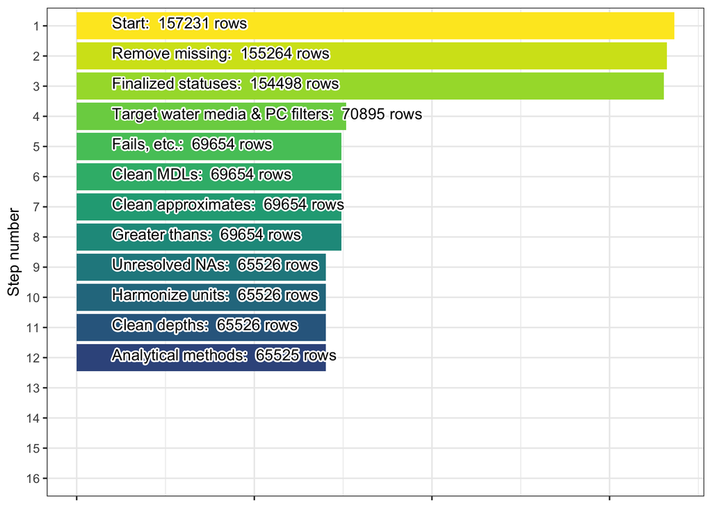

Bar plot showing the row count update for the current harmonization step.

### 10.2.10 Flag based on field methods

Next, `field_flag` cross-checks whether sample collection metadata (`ActivityTypeCode`, `SampleCollectionMethod.MethodName`, `SampleCollectionEquipmentName`) and `ResultSampleFractionText` agree with the assigned parameter category and analytical tier:

- `field_flag = 0` (**Discrete / consistent modality**): Discrete grab, bottle, Kemmerer, Van Dorn, or filter sampling for laboratory `Phycocyanin` (Tiers 0–1), or *in situ* sonde / discrete non-`"Dissolved"` subsample deployments for documented optical sensor parameters (`Phycocyanin (probe)`, `Phycocyanin relative fluorescence`, `Phycocyanin cell density`, Tier 1).
- `field_flag = 1` (**Integrated composite, pump, or modality/fraction mismatch**): Depth-integrated, cross-sectional EWI/multiple-vertical, or peristaltic/diaphragm pump samples (which vertically mix surface-buoyant cyanobacterial scums relative to optical sensing depths and can shear colonial filaments), as well as `Probe/Sensor` equipment listed under laboratory `Phycocyanin` or `"Dissolved"` sample fraction reported on an *in vivo* optical probe.
- `field_flag = 2` (**Inconclusive**): Tier 2 records or Tier 0–1 records where collection equipment and activity metadata are `"Unknown"`, `"Other"`, or `NA`.

No records are dropped in this step (0 rows dropped), leaving 65.5 thousand rows remaining.

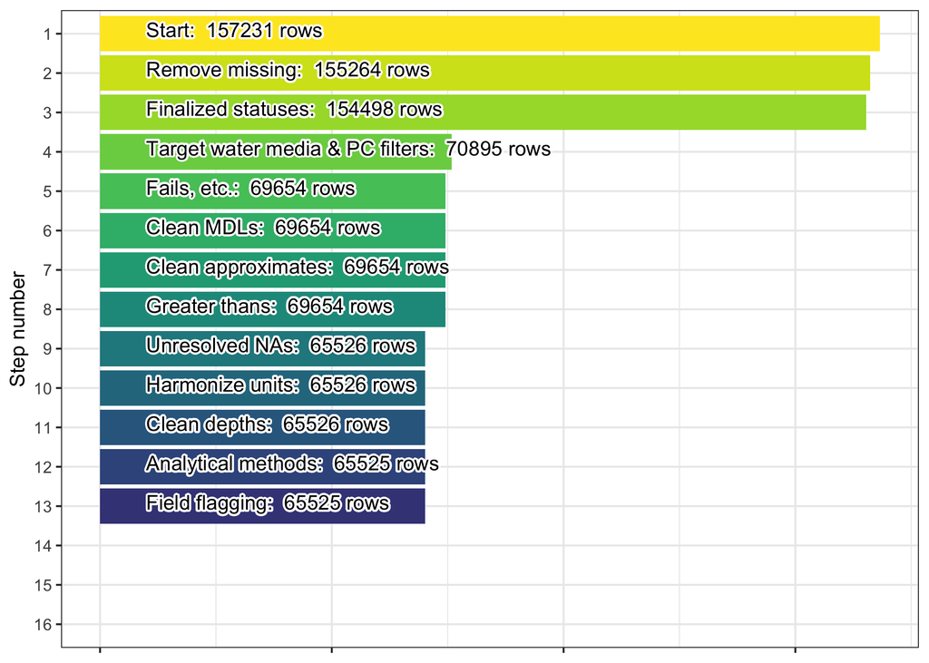

Bar plot showing the row count update for the current harmonization step.

### 10.2.11 Miscellaneous flag

For phycocyanin, `misc_flag` identifies two distinct data conditions that are held out from simultaneous replicate averaging during aggregation so end users can filter them explicitly:

- `misc_flag = 0`: Instantaneous/discrete observations within linear sensor calibration and non-scum surface-water bounds.
- `misc_flag = 1`: Continuous sonde daily `"Mean"` summary rows (`StatisticalBaseCode == "Mean"`), distinguishing multi-hour temporal averages from instantaneous point observations.
- `misc_flag = 2`: Extreme hypertrophic blooms or sensor linear-range ceiling exceedances (`> 1,000 ug/L` for extractive `Phycocyanin` per Chorus and Welker, 2021; `> 100 ug/L` for `Phycocyanin (probe)` and `> 100 RFU` matching YSI EXO linear ceilings per Zamyadi et al., 2012 and Foster et al., 2022; `> 200 IVFU` and `> 280,000 #/mL` matching YSI 6131 full-scale range). Note that records meeting both `misc_flag = 1` and `misc_flag = 2` criteria receive `misc_flag = 2`.

| **Parameter** | **Units** | **Flag = 1** | **Flag = 2** |
| --- | --- | --- | --- |
| Phycocyanin | ug/L | `StatisticalBaseCode == "Mean"` | `> 1,000 ug/L` |
| Phycocyanin (probe) | ug/L | `StatisticalBaseCode == "Mean"` | `> 100 ug/L` |
| Phycocyanin relative fluorescence | RFU, IVFU | `StatisticalBaseCode == "Mean"` | `> 100 RFU` or `> 200 IVFU` |
| Phycocyanin cell density | #/mL | `StatisticalBaseCode == "Mean"` | `> 280,000 #/mL` |

| parameter | harmonized_units | misc_flag | n |
| --- | --- | --- | --- |
| Phycocyanin | ug/L | 0 | 1425 |
| Phycocyanin | ug/L | 2 | 12 |
| Phycocyanin (probe) | ug/L | 0 | 18590 |
| Phycocyanin (probe) | ug/L | 1 | 6299 |
| Phycocyanin (probe) | ug/L | 2 | 200 |
| Phycocyanin cell density | #/mL | 0 | 2157 |
| Phycocyanin cell density | #/mL | 2 | 7 |
| Phycocyanin relative fluorescence | IVFU | 0 | 1656 |
| Phycocyanin relative fluorescence | RFU | 0 | 21578 |
| Phycocyanin relative fluorescence | RFU | 1 | 13580 |
| Phycocyanin relative fluorescence | RFU | 2 | 21 |

0 rows are dropped, leaving 65.5 thousand rows remaining.

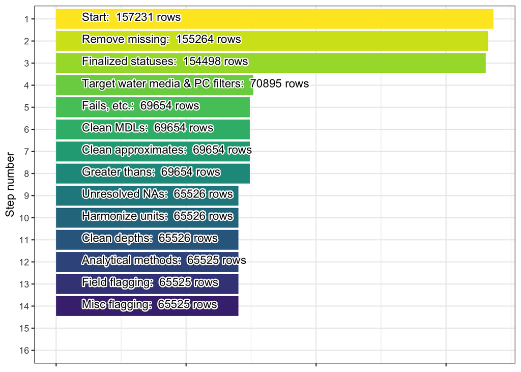

Bar plot showing the row count update for the current harmonization step.

### 10.2.12 Remove unrealistic values

Prior to finalizing the dataset, we apply modality-specific physical upper bounds rather than a single global `ug/L` cutoff, reflecting the distinct optical saturation and extraction regimes across measurement groups:

- **`Phycocyanin` (extractive laboratory pigment):** remove values `> 50,000 ug/L` (retaining extreme verified dissolved bloom/scum extracts up to `41,000 ug/L` under `misc_flag = 2`).
- **`Phycocyanin (probe)` (RWT-equivalent *in vivo* sensor output):** remove values `> 5,000 ug/L` (beyond commercial fluorometer linear/saturation ceilings; removing five saturated `POMO989_WQX` outliers and a `19,900 ug/L` `USGS-OH` data-entry typo).
- **`Phycocyanin relative fluorescence` (`RFU`/`IVFU`):** remove values `> 2,000` (`RFU` or `IVFU`).
- **`Phycocyanin cell density` (`#/mL`):** remove values `> 10,000,000 #/mL`.
- **Sampling depths:** remove any sampling depths `> 592 m`, the maximum lake depth in the United States (Larson, 1972).

6 rows are removed, leaving 65.5 thousand rows remaining.

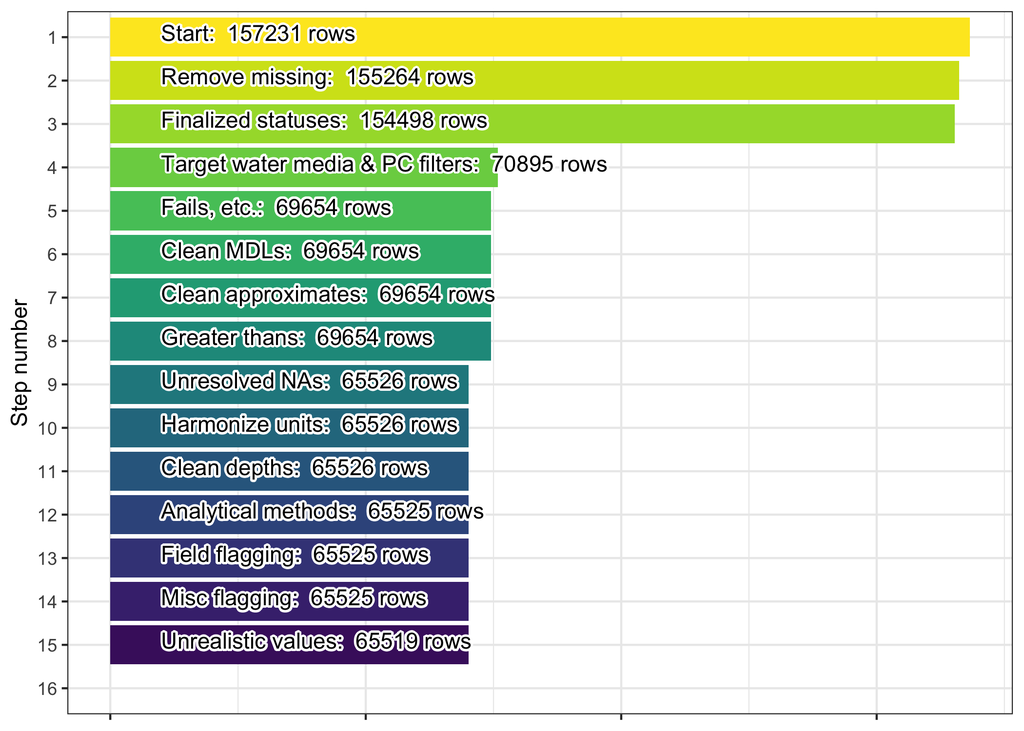

Bar plot showing the row count update for the current harmonization step.

### 10.2.13 Aggregate simultaneous records

The final step of phycocyanin harmonization aggregates simultaneous observations (matching across the 26 grouping columns `parameter`, `OrganizationIdentifier`, `MonitoringLocationIdentifier`, `MonitoringLocationTypeName`, `ResolvedMonitoringLocationTypeName`, `ActivityStartDate`, `ActivityStartTime.Time`, `ActivityStartTime.TimeZoneCode`, `harmonized_tz`, `harmonized_local_time`, `harmonized_utc`, `ActivityStartDateTime`, `harmonized_top_depth_value`, `harmonized_top_depth_unit`, `harmonized_bottom_depth_value`, `harmonized_bottom_depth_unit`, `harmonized_discrete_depth_value`, `harmonized_discrete_depth_unit`, `depth_flag`, `mdl_flag`, `approx_flag`, `greater_flag`, `tier`, `field_flag`, `misc_flag`, and `harmonized_units`) into mean values (`harmonized_value`), replicate counts (`harmonized_row_count`), and coefficients of variation (`harmonized_value_cv`), tagged by `subgroup_id` for back-joining with `p3_phyco_preagg_grouped`.

As with CDOM, records with `misc_flag` equal to `1` (daily means) or `2` (extreme hypertrophic or sensor-saturation ceiling exceedances) are held out from grouping and re-appended with `NA` in `subgroup_id`, `harmonized_row_count`, and `harmonized_value_cv`.

3689 rows are aggregated away, leaving 61.8 thousand rows remaining in the final harmonized phycocyanin dataset.

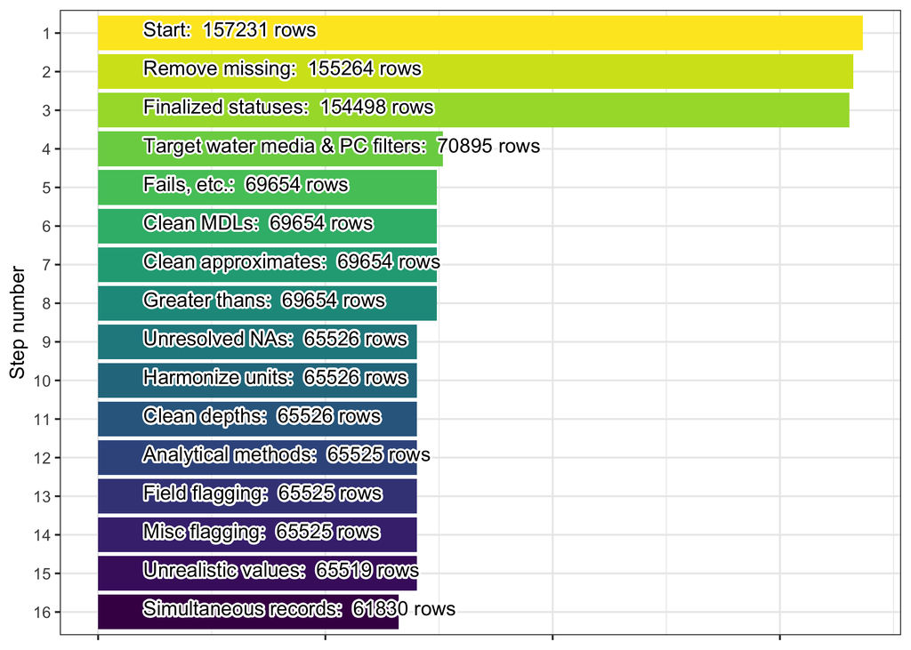

Bar plot showing the row count update for the current harmonization step.

### 10.2.14 Harmonized phycocyanin

At this point the harmonization of WQP phycocyanin data is complete. The figures below summarize the properties of the final aggregated dataset:

1. Distributions of positive harmonized values and coefficients of variation (CVs) across parameter groups, units, and tiers after simultaneous-record aggregation:

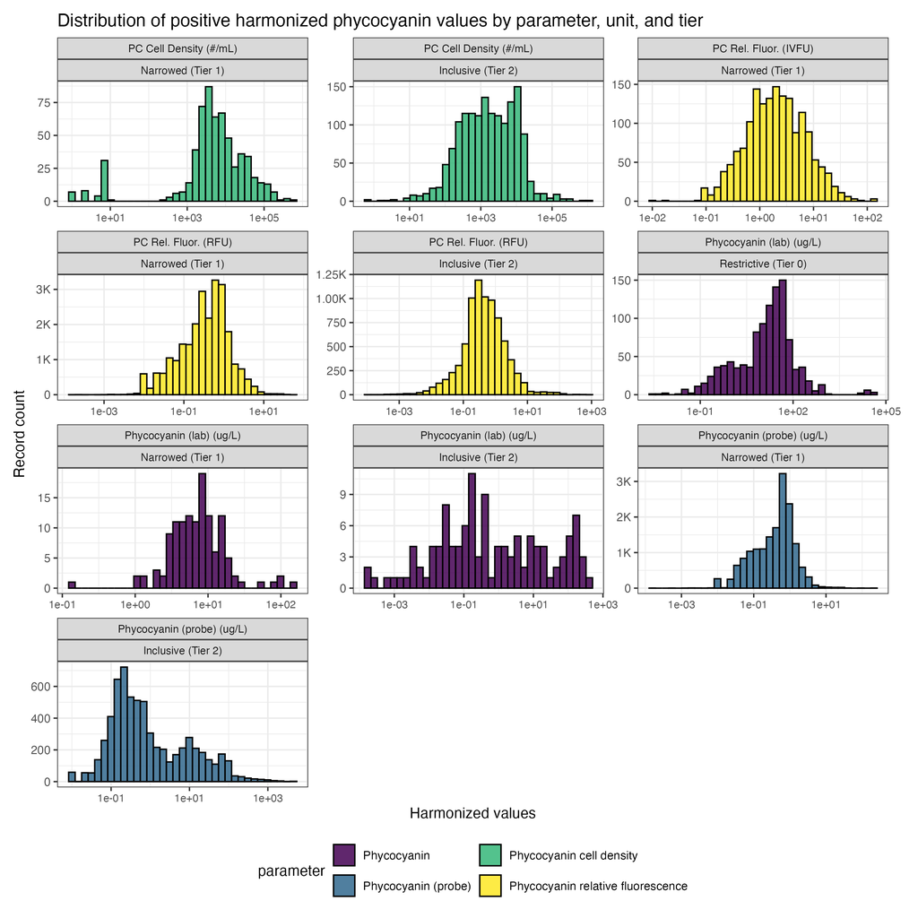

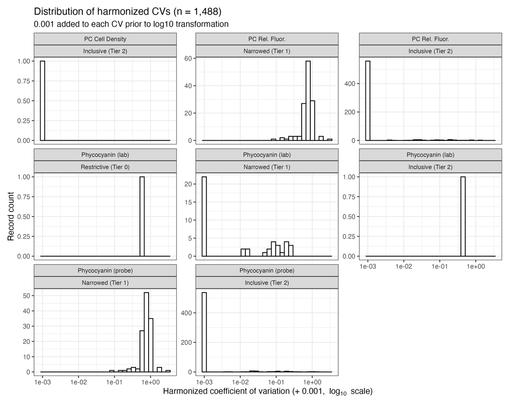

2. Geographic distribution of phycocyanin records by parameter and tier across the conterminous United States:

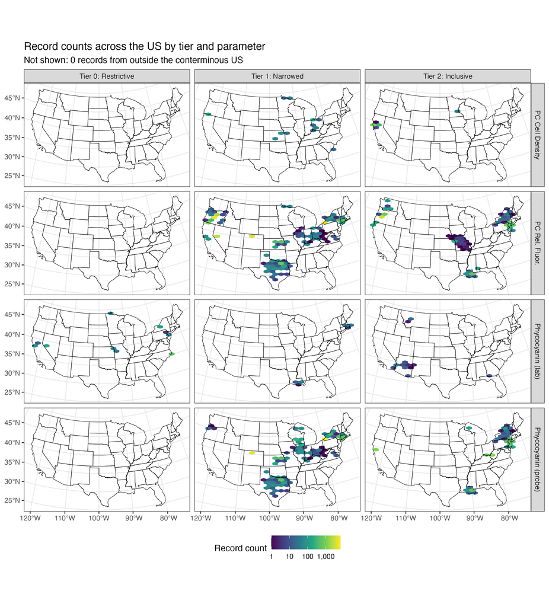

3. Temporal distributions across years, months, and days of the week by parameter and tier:

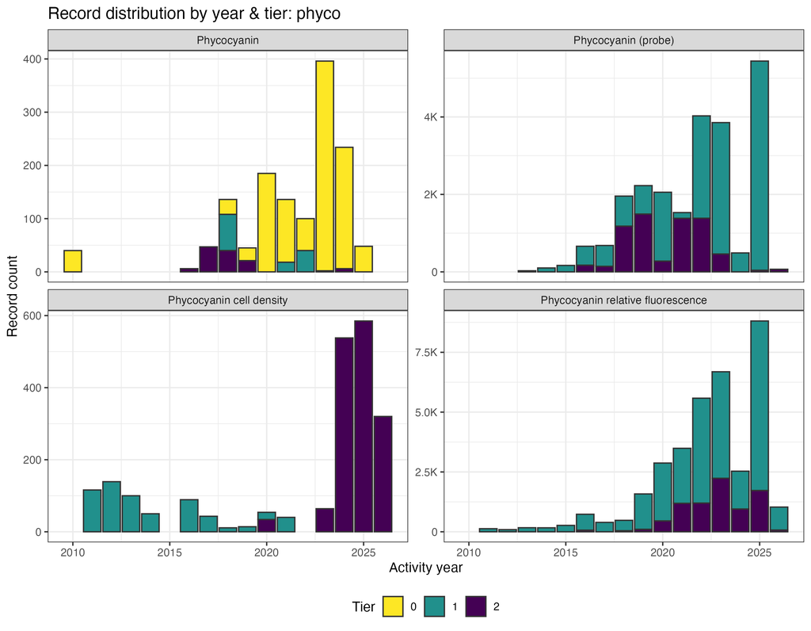

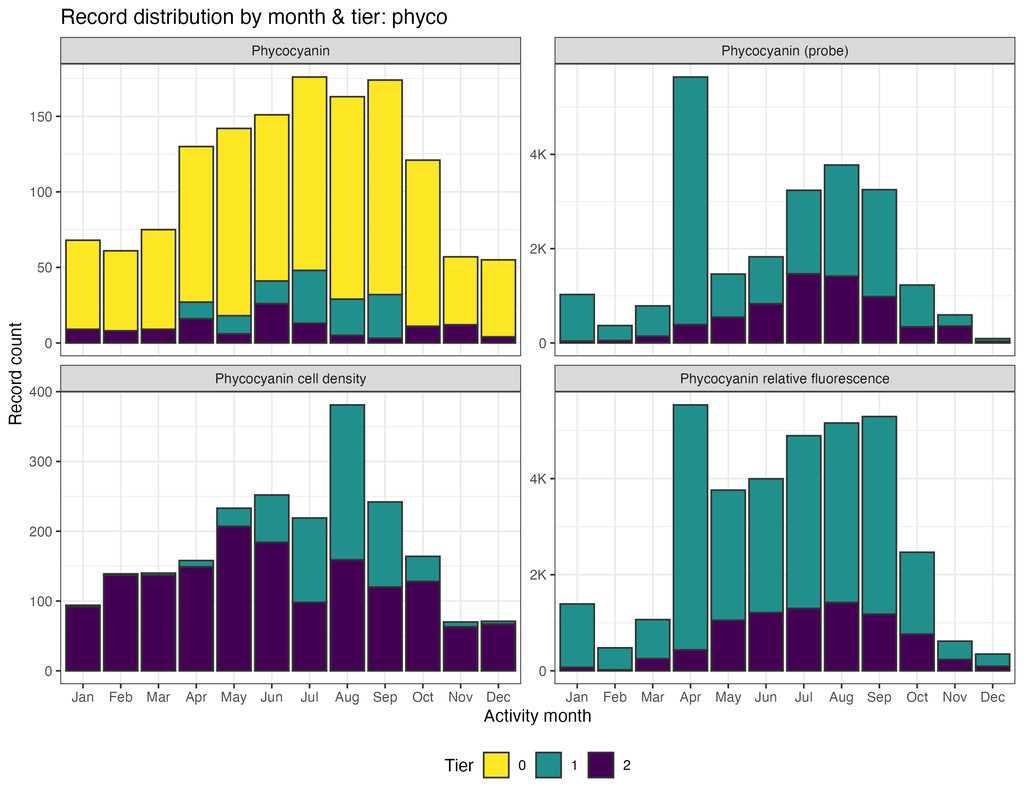

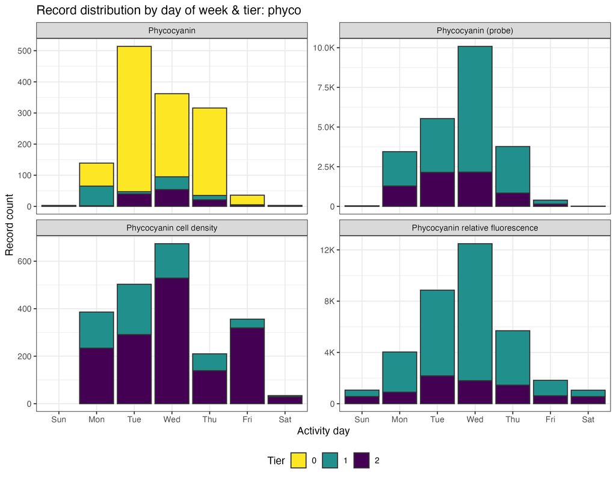

4. Sampling depth distributions (`harmonized_top_depth_value`, `harmonized_bottom_depth_value`, and `harmonized_discrete_depth_value`) by parameter, waterbody type, and tier:

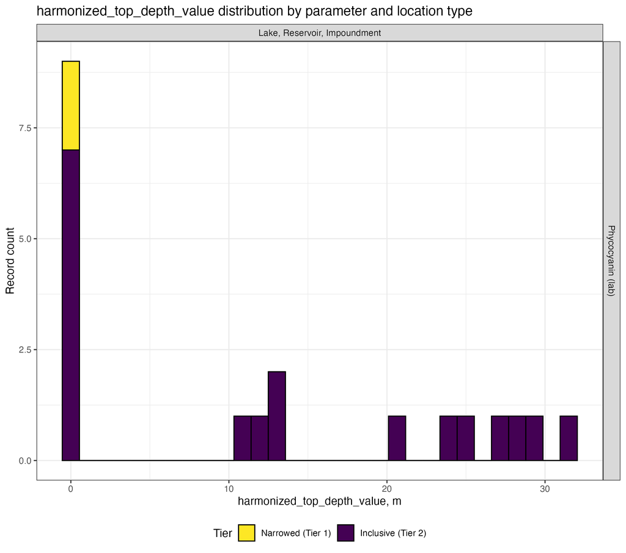

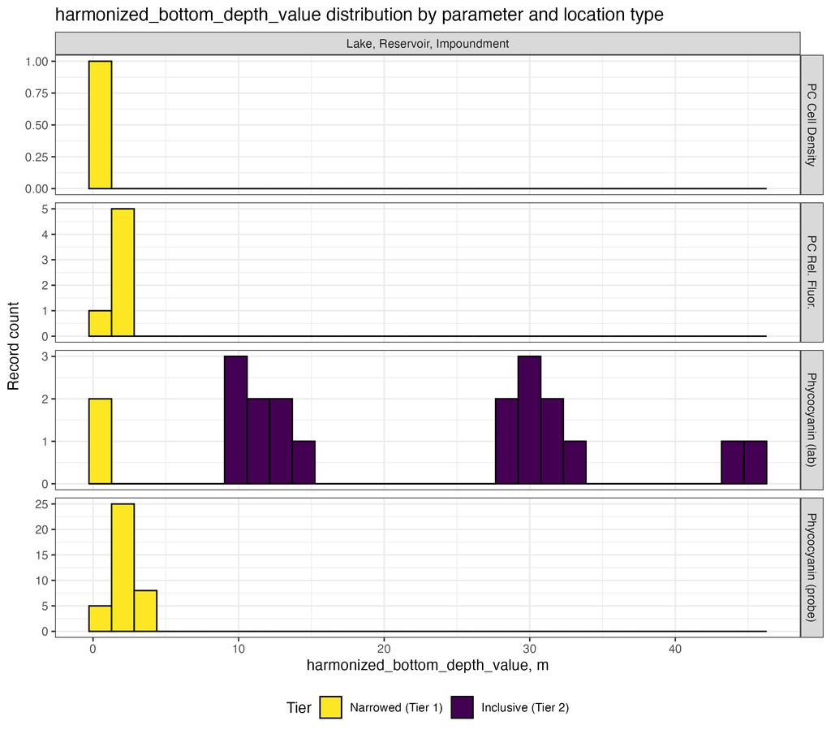

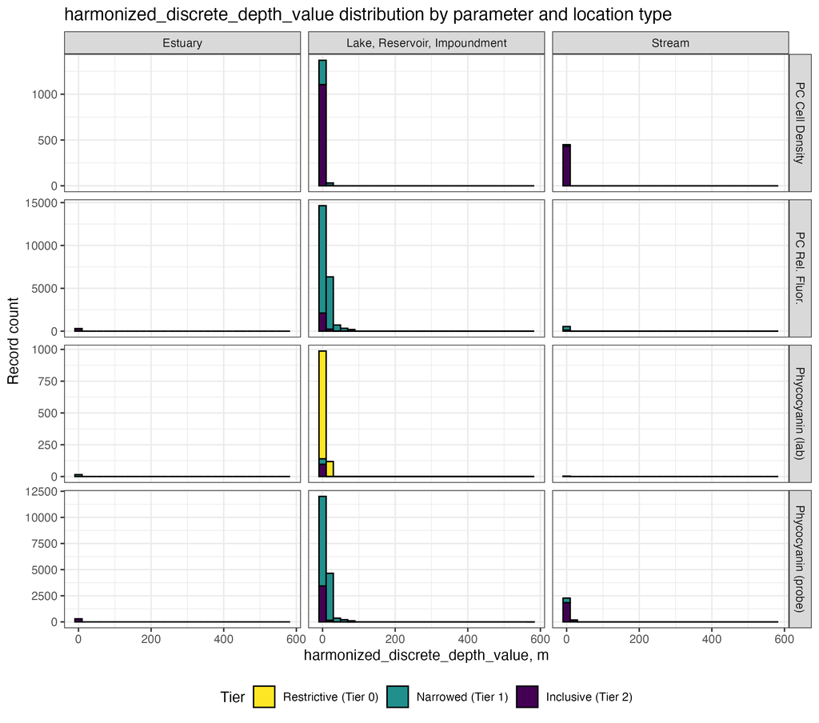